# BIOS15 – Conceptual Worksheet 2

The linear model: from parameters to biological meaning

Your name

2026-11-10

# 1 Goal

Read a linear model as a biological statement: distinguish fitted values from residual variation, interpret model parameters in their units, and separate effect size from statistical support.

# 2 1. Read the model as a biological statement

Consider:

$$y_i = \beta_0 + \beta_1 x_i + \varepsilon_i,
\qquad \varepsilon_i \sim N(0,\sigma^2)$$

The line gives the model’s expected value of the response. The vertical deviations of observations from that line are the residuals.

## 2.1 1a. Identify parts of a regression plot

On a regression plot, label or sketch observed $y$, predicted $\hat{y}$, one residual $\varepsilon$, and the fitted regression line.

**Your answer / sketch:**

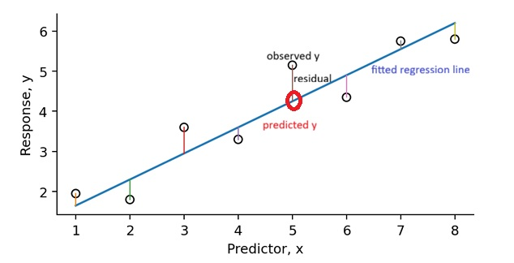

## 2.2 1b. Interpret the parameters

What does $\beta_0$ represent? What does $\beta_1$ represent?

**Your answer:**

$\beta_0$ is the intercept $\beta_1$ is the slope

## 2.3 1c. Interpret the units

If $x$ is leaf length (mm) and $y$ is leaf width (mm), what units must $\beta_1$ have?

**Your answer:**

The slope has units of mm/mm (millimetres of width per millimetre of length). This is a ratio of the same units, so it is dimensionless mathematically.

**[ChatGPT comment]** The important point is that the slope is not simply “no units”: it represents response units per predictor unit.

# 3 2. Intercept, slope, prediction and residual

Suppose:

$$\hat{y} = 0.5 + 0.4x$$

Here, $x$ is leaf length (mm) and $\hat{y}$ is predicted leaf width (mm).

## 3.1 2a. Interpret the slope

Translate the slope 0.4 into a biological sentence.

**Your answer:**

For every 1 mm increase in leaf length, the model predicts an increase of 0.4 mm in leaf width.

**[ChatGPT comment]** The slope is 0.4 mm/mm. It does not mean that width is always 40% of length; it describes the predicted change in width for a 1-mm increase in length.

## 3.2 2b. Interpret the intercept

What does the intercept 0.5 mean mathematically? Would it necessarily be biologically interesting if no leaves approach 0 mm in length?

**Your answer:**

It is the predicted width when leaf length is 0 mm. If no leaves approach 0 mm in length, the intercept may not have much biological meaning.

**[ChatGPT comment]** The intercept is the model’s predicted response at x = 0, not just an arbitrary number added to the width. Your point about its limited biological meaning is correct.

## 3.3 2c. Make a prediction

What width does the model predict for a 10-mm leaf?

$$\hat{y} =\text{4.5 mm}$$

## 3.4 2d. Calculate a residual

If that leaf actually has width 5.2 mm, calculate its residual using $\varepsilon = y - \hat{y}$.

$$\varepsilon = \text{0.7 mm}$$

## 3.5 2e. Interpret a negative residual

In words, what would a negative residual mean?

**Your answer:**

A negative residual means that the leaf’s observed width is smaller than the width predicted by the model.

# 4 3. What is actually assumed to be normal?

The model states:

$$\varepsilon \sim N(0,\sigma^2)$$

A student says: “Linear regression assumes that x and y are normally distributed.”

## 4.1 3a. Identify the normal quantity

What does the model equation actually say is assumed to follow a normal distribution?

**Your answer:**

The model assumes that the random errors (ε) follow a normal distribution. Residuals are the observed-minus-predicted differences that we calculate and use to assess this assumption.

## 4.2 3b. Consider a skewed predictor

Could $x$ itself be strongly skewed and the Gaussian linear model still be appropriate? Explain.

**Your answer:**

Yes. The predictor (x) does not itself need to be normally distributed. The model assumes that the errors around the expected response are approximately normally distributed (along with other model assumptions).

## 4.3 3c. Use residual plots

Why do residual plots help us assess whether the model is appropriate?

**Your answer:**

Residual plots help us see whether the model misses systematic patterns in the data—for example, curvature or changing residual spread. They help assess whether the model assumptions are reasonable.

# 5 4. Same effect, different statistical support

The three datasets below were generated with the same underlying slope. What differs is residual scatter and/or sample size.

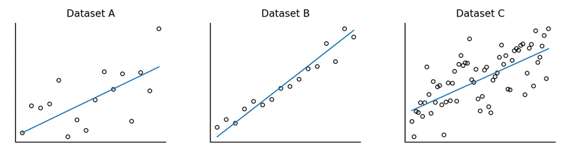

## 5.1 4a. Compare precision

Which dataset (A, B or C) should give the most precise estimate of $\beta_1$? Why?

**Your answer:**

Dataset B should give the most precise estimate of β₁ because its points are close to the fitted line, indicating relatively small residual variation.

## 5.2 4b. Factors affecting statistical support

Which features of a dataset affect the statistical support for a non-zero slope?

**Your answer:**

Sample size, residual variation (or residual standard deviation), the spread of x-values, and the size of the estimated slope.

## 5.3 4c–4e. Compare two studies

| Study | Estimated slope $\hat{\beta}_1$ | p-value |
| --- | --- | --- |
| A | 0.50 | 0.08 |
| B | 0.05 | < 0.001 |

**4c.** Which study has the larger estimated effect?

**Your answer:** Study A has the larger estimated effect (slope = 0.50). Its p-value (0.08) provides weaker statistical evidence against a zero slope than Study B’s p-value.

**4d.** Which has stronger statistical evidence against $\beta_1 = 0$?

**Your answer:** Study B has stronger statistical evidence against β₁ = 0 because its p-value is smaller, although its estimated slope (0.05) is also smaller.

**4e.** Can you decide which result is more biologically important from the p-values alone? Explain.

**Your answer:**

No. Effect size and biological context are also important considerations.

# 6 5. What does $R^2$ tell us?

The two datasets below have approximately the same slope, but different amounts of scatter around the regression line.

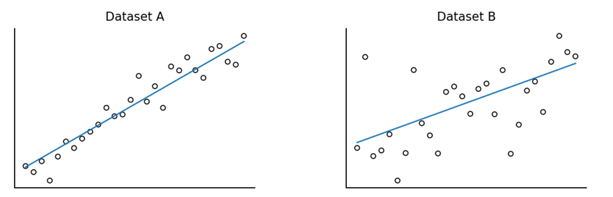

## 6.1 5a. Compare $R^2$

Which dataset (A or B) should have the larger $R^2$? Why?

**Your answer:**

$R^2$ is larger in A, because more variation in y can be explained by x.

## 6.2 5b. Slope and $R^2$

Does a large $R^2$ necessarily mean that the slope is steep?

- Yes
- No

Explain:

It describes the proportion of variation in the response variable (y) explained by the fitted model. It does not tell us whether the slope is steep.

## 6.3 5c. Interpret $R^2$

Complete: $R^2 = 0.43$ means that **43 %** of the variation in **y** is explained by **x**.

# 7 6. Turn statistics back into biology

Poor Results sentence:

> “There was a significant relationship between leaf length and leaf width (P < 0.001).”

Suppose the model gives:

$$\hat{\beta}_1 = 0.43 \pm 0.04\ \text{mm/mm},
\qquad R^2 = 0.43$$

## 7.1 6a. Identify missing information

What biologically useful information is missing from the original sentence?

**Your answer:**

It does not quantify the size of the relationship between leaf length and leaf width.

## 7.2 6b. Rewrite the result

Rewrite the result so that the biological effect is quantified and interpretable.

**Your revised Results sentence:**

For each 1 mm increase in leaf length, predicted leaf width increases by 0.43 mm (SE = 0.04 mm/mm). The model explains 43% of the variation in leaf width (R² = 0.43; P < 0.001).

**[ChatGPT comment]** Your original sentence reversed the response and predictor: R² describes variation in leaf width (y) explained by the model using leaf length (x). A stronger result statement also reports the estimated slope and its units, not only R² and statistical significance.

# 8 Exit ticket

Complete: “When I see the output of a linear model, the first quantity I want to interpret biologically is…”

**Your answer:**

Effect size.

# 9 Additional questions

Questions to revisit during the R exercise / after the lecture:

*Write here.*

# 10 R practical: fitting a linear model (from lecture notes)

Simulate data from a known linear relationship, fit the model, and inspect its predictions and residuals.

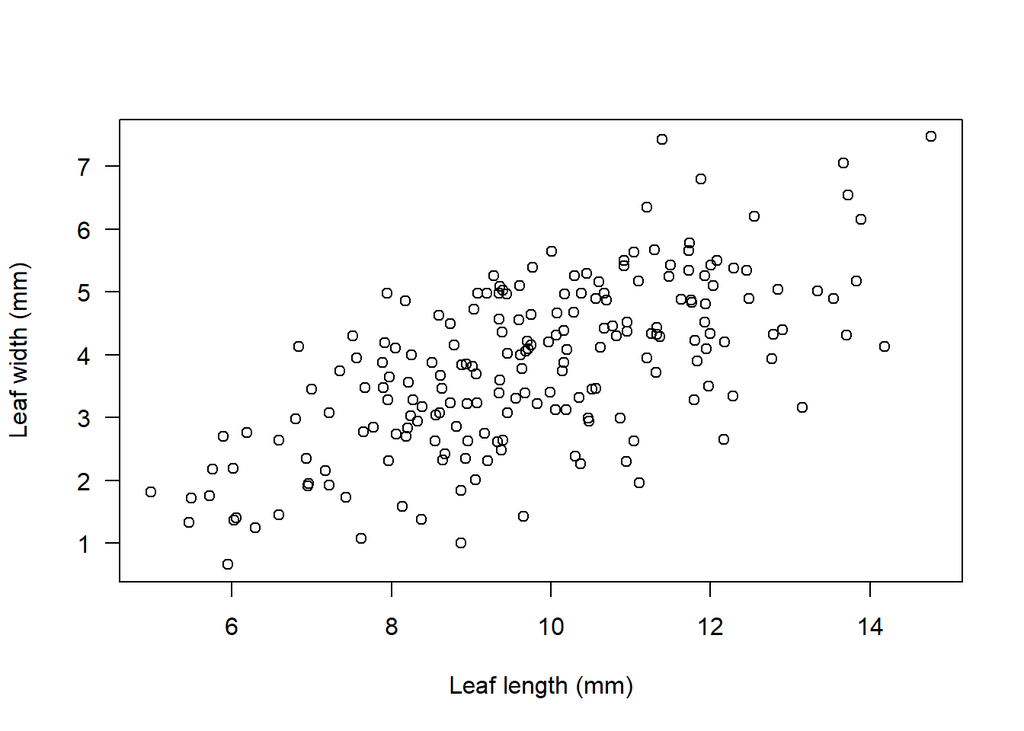

```r
# Make the random numbers reproducible: rerunning this code gives the same data.
set.seed(85)
# Generate 200 predictor values (x), with mean 10 and standard deviation 2.
x <- rnorm(n = 200, mean = 10, sd = 2)
# Generate response values (y): 0.4 is the underlying slope, plus random noise.
y <- 0.4 * x + rnorm(200, 0, 1)

# Plot the observations; each point represents one paired x and y value.
plot(x, y, las = 1,
     xlab = "Leaf length (mm)",
     ylab = "Leaf width (mm)")
```

Fit the model and inspect its estimates and diagnostics.

```r
# Fit a linear model: lm() estimates a straight-line relationship between y and x.
# In the formula y ~ x, y is the response and x is the predictor.
m <- lm(y ~ x)
# Display the model object's components, such as coefficients and residuals.
# str(m)
# Extract the estimated coefficients: first the intercept, then the slope for x.
cf <- coef(m)
# Print the intercept (beta_0) and slope (beta_1).
cf
```

```
## (Intercept)           x
##  -0.4011431   0.4333027
```

```r
# Print model results, including coefficient uncertainty and R-squared.
summary(m)
```

```
##
## Call:
## lm(formula = y ~ x)
##
## Residuals:
##      Min       1Q   Median       3Q      Max
## -2.45122 -0.68319  0.02913  0.69861  2.88937
##
## Coefficients:
##             Estimate Std. Error t value Pr(>|t|)
## (Intercept) -0.40114    0.35186   -1.14    0.256
## x            0.43330    0.03538   12.25   <2e-16 ***
## ---
## Signif. codes:  0 '***' 0.001 '**' 0.01 '*' 0.05 '.' 0.1 ' ' 1
##
## Residual standard error: 0.9912 on 198 degrees of freedom
## Multiple R-squared:  0.4311, Adjusted R-squared:  0.4282
## F-statistic:   150 on 1 and 198 DF,  p-value: < 2.2e-16
```

Read the printed output from top to bottom:

- `cf`: `(Intercept)` is $\beta_0$; `x` is $\beta_1$, the slope.
- `Estimate`: coefficient value. `Std. Error`: its uncertainty. `t value` = estimate / standard error. `Pr(>|t|)`: p-value for testing whether the coefficient is zero.
- `Residuals`: observed minus predicted values; the five numbers summarize their spread.
- `Residual standard error`: typical residual size, in `y` units.
- `Multiple R-squared`: fraction of variation in `y` explained by the model. `Adjusted R-squared` adjusts for the number of predictors.
- `F-statistic` and its p-value: test whether the model with `x` improves on a model with no predictor. With one predictor, this tests the same zero-slope relationship as the `x` row.

So the fitted line is `y = -0.401 + 0.433 * x`. The slope says predicted `y` increases by about 0.433 units per one-unit increase in `x`. The intercept is predicted `y` at `x = 0`, which may not be meaningful if zero is outside the observed range.

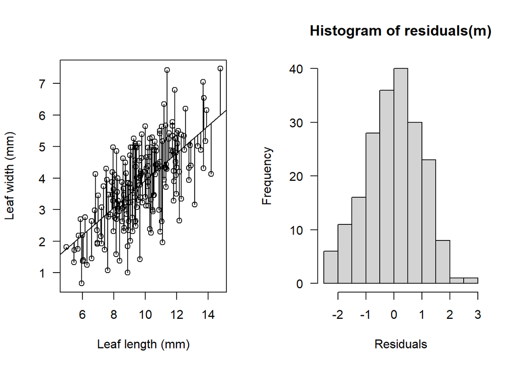

```r
# Predict y for every x value used to fit the model.
predvals <- predict(m)
# Arrange the next two plots side by side.
par(mfrow = c(1, 2))
#par(mfrow=c(2,2))
# Start the first panel with a scatterplot of the observed values.
plot(x, y, las = 1,
     xlab = "Leaf length (mm)",
     ylab = "Leaf width (mm)")
# Add the fitted straight line from model m to the current scatterplot.
abline(m)
# Draw residuals as vertical segments from each observed y to its prediction.
segments(x, y, x, predvals)
# Plot a histogram to inspect the distribution of the model residuals.
hist(residuals(m), xlab = "Residuals", las = 1)
```

```r
# Return to a single-panel plotting layout.
par(mfrow = c(1, 1))
```

Draw the fitted line only across the observed range of `x`. .To keep the regression line within the data range, it is better to make predictions for new values of `x` spanning the data range and add the regression line using the lines function.

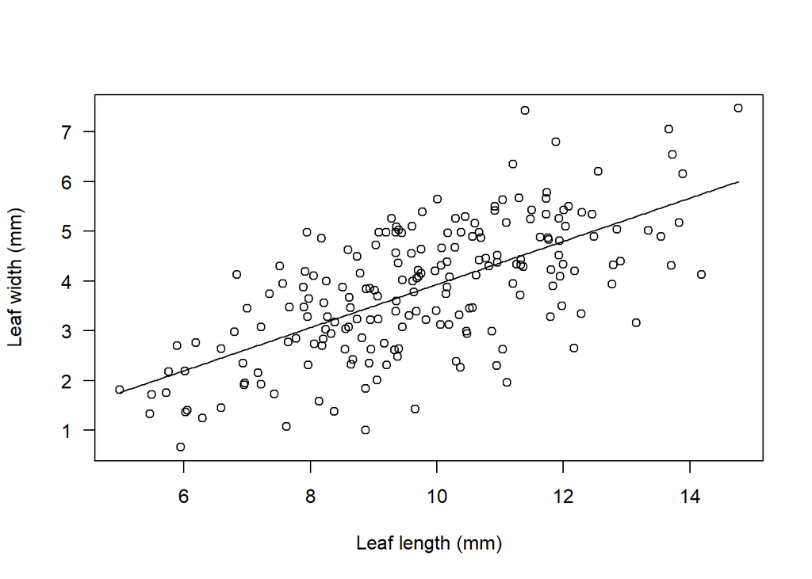

```r
# Make 200 evenly spaced x values between the smallest and largest observed x.
newx <- seq(min(x), max(x), length.out = 200)
# Use the fitted model to predict y at each new x value.
predy <- predict(m, newdata = data.frame(x = newx))

# Create the scatterplot first; lines() below adds to this existing plot.
plot(x, y, las = 1,
     xlab = "Leaf length (mm)",
     ylab = "Leaf width (mm)")
# Connect the predictions to show the fitted line across the observed x range.
lines(newx, predy)
```

# 11 OPTIONAL EXERCISE:

Use non-parametric bootstrapping to derive a standard error for the slope of the linear regression above. Compare a bootstrap estimate of the slope’s standard error with the model output.

```r
df = data.frame(x, y)
colnames(df)<-c('x', 'y')

# sample from this dataset (with replacement)
newdf = df[sample(nrow(df), 200, replace=TRUE), ]
colnames(newdf)<-c('x', 'y')

# fit the model
nm <- lm(y ~ x, data = newdf)
coef(nm)
```

```
## (Intercept)           x
##  -0.3400589   0.4254261
```

```r
set.seed(86)  # Make the results reproducible

boot_slopes <- replicate(1000, {
  # Sample rows with replacement
  newdf <- df[sample(nrow(df), replace = TRUE), ]

  # Fit y on x and save the slope coefficient
  coef(lm(y ~ x, data = newdf))[2]
})

# Standard deviation of bootstrap slopes = bootstrap standard error
sd(boot_slopes)
```

```
## [1] 0.0352875
```

Interpret the slope in its units and compare the variance explained by the model with `R-squared`.

```r
# The slope: expected change in y for a one-unit increase in x.
cf[2]
```

```
##         x
## 0.4333027
```

```r
# The expected change in y for an increase in x equal to one standard deviation.
cf[2] * sd(x)
```

```
##         x
## 0.8606095
```

```r
# In a simple linear regression, squared correlation equals the model's R-squared.
cor(x, y)^2
```

```
## [1] 0.4310643
```

```r
# Get the fitted (predicted) y value for each observed x value.
y_hat <- predict(m)
# Compare variance among predictions with the total variance in observed y.
var(y_hat) / var(y)
```

```
## [1] 0.4310643
```

```r
# Compute the variance explained by the fitted slope in this simple model.
cf[2]^2 * var(x)
```

```
##         x
## 0.7406487
```

# 12 Exercise: Fit a regression to real data

Choose a dataset with a continuous response and a continuous predictor. Fit a simple linear regression, interpret the slope, make a figure with the fitted line, and write a short Methods and Results section.

If you do not have a dataset, use the bird data below. It contains brain mass and body mass for male and female birds. Body parts often scale with body size according to a power relationship:

$$y = a x^b$$

Taking logs makes this a straight-line relationship:

$$\log(y) = \log(a) + b\log(x)$$

Here, the slope $b$ describes how brain mass scales with body mass. For example, a slope of 0.55 means that a 10% increase in body mass is associated with approximately a 5.5% increase in brain mass.

### 12.0.1 1. Load the data and fit the models

```r
# Read the bird data and inspect the first rows and column names.
birds <- read.csv("Supplementary/bird_allometry.csv")
head(birds)
```

```
##               Genus_Species Sex brain_mass body_mass
## 1        Accipiter_gentilis   f   7.686143 1049.1571
## 2        Accipiter_gentilis   m   7.618500  678.2833
## 3           Accipiter_nisus   f   3.112797  252.1263
## 4           Accipiter_nisus   m   2.637390  136.1441
## 5        Accipiter_striatus   f   5.700000  520.0000
## 6 Acridotheres_cristatellus   m   2.310000  122.3800
```

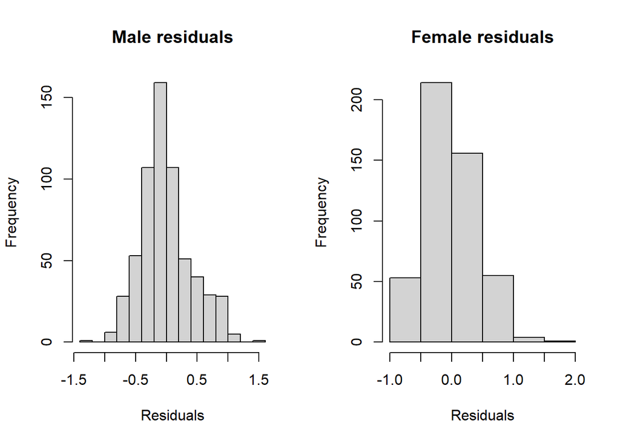

```r
# Split the data by sex, then fit a line to log brain mass and log body mass.
males <- birds[birds$Sex == "m", ]
females <- birds[birds$Sex == "f", ]
mm <- lm(log(brain_mass) ~ log(body_mass), data = males)
mf <- lm(log(brain_mass) ~ log(body_mass), data = females)

# Inspect residuals and model summaries for both groups.
par(mfrow = c(1, 2))
hist(residuals(mm), main = "Male residuals", xlab = "Residuals")
hist(residuals(mf), main = "Female residuals", xlab = "Residuals")
```

```r
par(mfrow = c(1, 1))
summary(mm)
```

```
##
## Call:
## lm(formula = log(brain_mass) ~ log(body_mass), data = males)
##
## Residuals:
##      Min       1Q   Median       3Q      Max
## -1.27532 -0.24778 -0.06226  0.19858  1.59801
##
## Coefficients:
##                 Estimate Std. Error t value Pr(>|t|)
## (Intercept)    -1.905598   0.045493  -41.89   <2e-16 ***
## log(body_mass)  0.550206   0.009898   55.59   <2e-16 ***
## ---
## Signif. codes:  0 '***' 0.001 '**' 0.01 '*' 0.05 '.' 0.1 ' ' 1
##
## Residual standard error: 0.4144 on 613 degrees of freedom
## Multiple R-squared:  0.8345, Adjusted R-squared:  0.8342
## F-statistic:  3090 on 1 and 613 DF,  p-value: < 2.2e-16
```

```r
summary(mf)
```

```
##
## Call:
## lm(formula = log(brain_mass) ~ log(body_mass), data = females)
##
## Residuals:
##      Min       1Q   Median       3Q      Max
## -0.90255 -0.26201 -0.03523  0.24946  1.93514
##
## Coefficients:
##                Estimate Std. Error t value Pr(>|t|)
## (Intercept)    -1.99844    0.05532  -36.12   <2e-16 ***
## log(body_mass)  0.57529    0.01184   48.57   <2e-16 ***
## ---
## Signif. codes:  0 '***' 0.001 '**' 0.01 '*' 0.05 '.' 0.1 ' ' 1
##
## Residual standard error: 0.4116 on 481 degrees of freedom
## Multiple R-squared:  0.8307, Adjusted R-squared:  0.8303
## F-statistic:  2359 on 1 and 481 DF,  p-value: < 2.2e-16
```

In each coefficient table, the estimate beside `log(body_mass)` is the allometric slope. Compare the estimates and standard errors.

*What kind of analysis could we do to directly estimate the difference in slope between males and females?* To test the sex difference in slopes directly, fit a model with a `Sex` by body mass interaction:

```r
# The interaction tests whether the body-mass slope differs by sex.
sex_model <- lm(log(brain_mass) ~ log(body_mass) * Sex, data = birds)
summary(sex_model)
```

```
##
## Call:
## lm(formula = log(brain_mass) ~ log(body_mass) * Sex, data = birds)
##
## Residuals:
##      Min       1Q   Median       3Q      Max
## -1.27532 -0.25489 -0.04968  0.22496  1.93514
##
## Coefficients:
##                           Estimate Std. Error t value Pr(>|t|)
## (Intercept)               -1.99844    0.05550 -36.009   <2e-16 ***
## log(body_mass)             0.57529    0.01188  48.421   <2e-16 ***
## Sexm                       0.09284    0.07165   1.296    0.195
## Sexunknown                -0.14422    0.13921  -1.036    0.300
## log(body_mass):Sexm       -0.02508    0.01544  -1.624    0.105
## log(body_mass):Sexunknown  0.04253    0.02807   1.515    0.130
## ---
## Signif. codes:  0 '***' 0.001 '**' 0.01 '*' 0.05 '.' 0.1 ' ' 1
##
## Residual standard error: 0.4129 on 1178 degrees of freedom
## Multiple R-squared:  0.838,  Adjusted R-squared:  0.8374
## F-statistic:  1219 on 5 and 1178 DF,  p-value: < 2.2e-16
```

In this model, the `log(body_mass):Sex` interaction coefficient estimates the slope difference from the reference sex (the first `Sex` factor level). Its p-value tests whether the slopes differ. The separate male and female models are useful for describing each slope; the interaction model provides a direct comparison. If `Sex` includes an `unknown` category, the output will also show its intercept and slope differences relative to the reference sex.

Because both measurements are log-transformed, the slope is an allometric exponent: it describes the approximate percentage change in brain mass for a percentage change in body mass. For the reference group, the slope is 0.57529, so a 10% increase in body mass is associated with approximately a 5.75% increase in brain mass (0.57529 × 10%). The exact power-law calculation is $1.1^{0.57529} - 1$, or about 5.6%.

### 12.0.2 2. Make a figure and inspect unusual points

Plot log brain mass against log body mass, use a different color for each sex, and add each fitted line. Identify any species that appear far from the main cloud, especially at the upper right. Use the species names in `birds$Genus_Species` to find them.

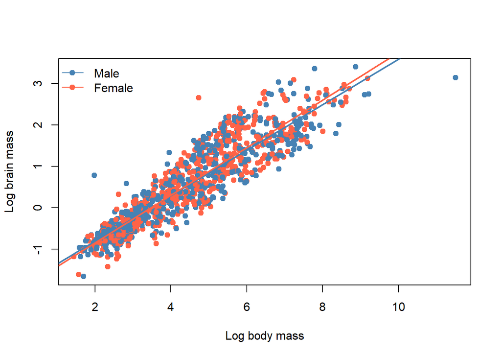

```r
# Plot the log-transformed measurements, distinguishing the sexes by color.
plot(log(brain_mass) ~ log(body_mass), data = birds,
     col = ifelse(birds$Sex == "m", "steelblue", "tomato"),
     pch = 19, xlab = "Log body mass", ylab = "Log brain mass")
abline(mm, col = "steelblue", lwd = 2)
abline(mf, col = "tomato", lwd = 2)
legend("topleft", legend = c("Male", "Female"),
       col = c("steelblue", "tomato"), pch = 19, lty = 1, bty = "n")
```

To check the names of possible outlying species, inspect the rows with the largest log body masses or brain masses:

```r
birds[order(log(birds$body_mass), decreasing = TRUE),
      c("Genus_Species", "Sex", "brain_mass", "body_mass")][1:10, ]
```

```
##                 Genus_Species     Sex brain_mass body_mass
## 1053         Struthio_camelus       m     23.290  99000.00
## 130             Ardeotis_kori       m     15.630  10000.00
## 516               Gyps_fulvus unknown     22.850   9750.00
## 378               Cygnus_olor       m     15.432   9000.00
## 590  Leptoptilos_crumeniferus       m     30.140   7130.00
## 376        Cygnus_columbianus       f     17.750   6000.00
## 129             Ardeotis_kori       f     12.940   5540.00
## 379               Cygnus_olor unknown     14.500   5528.25
## 113         Aquila_chrysaetos unknown     18.600   5273.10
## 515            Gyps_africanus       f     19.600   5270.00
```

### 12.0.3 3. Write up your analysis

**Methods:** We expected brain mass to scale with body mass according to a power-law relationship, `brain mass = a × body mass^b`. We log-transformed both variables and fitted separate linear regression models for males and females. We also fitted a model with a body-mass by sex interaction to test whether the slopes differed. The slope, *b*, describes how brain mass scales with body mass.

**Results:** Brain mass scaled with body mass (Fig. 1). In males, brain mass increased by approximately 5.5% for every 10% increase in body mass (slope = 0.55, SE = 0.010), and body mass explained 83.5% of the variation in brain mass. The estimated slope was slightly steeper in females (slope = 0.57, SE = 0.012), but the interaction model did not provide clear evidence that the male and female slopes differed (male slope difference = -0.025, SE = 0.015, *t* = -1.62, *p* = 0.105). The output also included an `unknown` sex category; its slope difference from the reference category was not statistically clear (*p* = 0.130).

# 13 Optional exercise: How measurement error affects the slope

The usual linear model assumes that the predictor, `x`, is measured without error. If the measured predictor contains random error, the fitted slope is often pulled toward zero. Random measurement error in the response, `y`, usually makes the estimates less precise but does not systematically pull the slope toward zero.

First simulate one dataset and fit the model before adding measurement error:

```r
set.seed(10)
n <- 200
beta0 <- 2                 # True intercept
beta1 <- 1.5               # True slope
x_true <- rnorm(n, 0, 1)   # True predictor values
y_true <- beta0 + beta1 * x_true + rnorm(n, 0, 0.5)

# With no measurement error in x, the estimated slope should be near beta1.
summary(lm(y_true ~ x_true))
```

```
##
## Call:
## lm(formula = y_true ~ x_true)
##
## Residuals:
##      Min       1Q   Median       3Q      Max
## -1.27123 -0.33491 -0.01619  0.33467  1.25044
##
## Coefficients:
##             Estimate Std. Error t value Pr(>|t|)
## (Intercept)  2.05816    0.03601   57.15   <2e-16 ***
## x_true       1.51087    0.03760   40.19   <2e-16 ***
## ---
## Signif. codes:  0 '***' 0.001 '**' 0.01 '*' 0.05 '.' 0.1 ' ' 1
##
## Residual standard error: 0.5056 on 198 degrees of freedom
## Multiple R-squared:  0.8908, Adjusted R-squared:  0.8902
## F-statistic:  1615 on 1 and 198 DF,  p-value: < 2.2e-16
```

Now add random error to the predictor and compare the fitted slope with the no-error estimate:

```r
error_sd <- 0.5
x_measured <- x_true + rnorm(n, 0, error_sd)
summary(lm(y_true ~ x_measured))
```

```
##
## Call:
## lm(formula = y_true ~ x_measured)
##
## Residuals:
##      Min       1Q   Median       3Q      Max
## -2.54447 -0.60959 -0.06045  0.59303  1.90589
##
## Coefficients:
##             Estimate Std. Error t value Pr(>|t|)
## (Intercept)  2.00997    0.06011   33.44   <2e-16 ***
## x_measured   1.14166    0.05384   21.21   <2e-16 ***
## ---
## Signif. codes:  0 '***' 0.001 '**' 0.01 '*' 0.05 '.' 0.1 ' ' 1
##
## Residual standard error: 0.8459 on 198 degrees of freedom
## Multiple R-squared:  0.6943, Adjusted R-squared:  0.6928
## F-statistic: 449.7 on 1 and 198 DF,  p-value: < 2.2e-16
```

Repeat this over several error sizes. The reliability ratio is the proportion of variance in the measured predictor that comes from the true predictor. Dividing the observed slope by this ratio gives a simple correction under the assumptions of this simulation:

$$K = \frac{\mathrm{Var}(x_{true})}{\mathrm{Var}(x_{true}) +
\mathrm{Var}(error)}, \qquad
\beta_{corrected} = \frac{\beta_{observed}}{K}$$

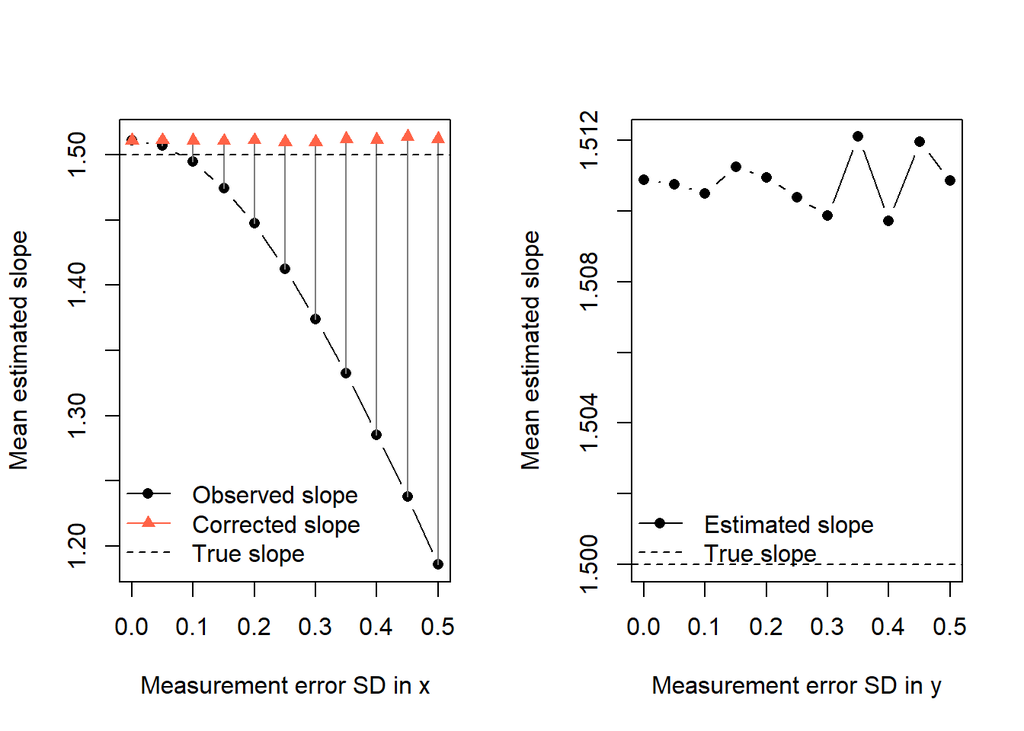

```r
set.seed(11)
error_sds <- seq(0, 0.5, by = 0.05)
n_repeats <- 500
slope_x <- corrected_x <- slope_y <- numeric(length(error_sds))

for (i in seq_along(error_sds)) {
  error_sd <- error_sds[i]

  # Repeat adding error to x and record the fitted slope each time.
  slopes_with_x_error <- replicate(n_repeats, {
    x_measured <- x_true + rnorm(n, 0, error_sd)
    coef(lm(y_true ~ x_measured))[2]
  })
  slope_x[i] <- mean(slopes_with_x_error)

  # Correct the average slope using the reliability ratio K.
  K <- var(x_true) / (var(x_true) + error_sd^2)
  corrected_x[i] <- slope_x[i] / K

  # Add the same size of random error to y instead and record the slopes.
  slopes_with_y_error <- replicate(n_repeats, {
    y_measured <- y_true + rnorm(n, 0, error_sd)
    coef(lm(y_measured ~ x_true))[2]
  })
  slope_y[i] <- mean(slopes_with_y_error)
}

# Compare the uncorrected and corrected estimates when x has measurement error.
par(mfrow = c(1, 2))
plot(error_sds, slope_x, type = "b", pch = 16,
     ylim = range(slope_x, corrected_x, beta1),
     xlab = "Measurement error SD in x", ylab = "Mean estimated slope")
segments(error_sds, slope_x, error_sds, corrected_x, col = "grey50")
points(error_sds, corrected_x, pch = 17, col = "tomato")
abline(h = beta1, lty = 2)
legend("bottomleft", c("Observed slope", "Corrected slope", "True slope"),
       pch = c(16, 17, NA), lty = c(1, 1, 2),
       col = c("black", "tomato", "black"), bty = "n")

# Compare slopes when the same sizes of measurement error are added to y.
plot(error_sds, slope_y, type = "b", pch = 16,
     ylim = range(slope_y, beta1),
     xlab = "Measurement error SD in y", ylab = "Mean estimated slope")
abline(h = beta1, lty = 2)
legend("bottomleft", c("Estimated slope", "True slope"),
       pch = c(16, NA), lty = c(1, 2), bty = "n")
```

```r
par(mfrow = c(1, 1))
```

**Interpretation:** As error in `x` increases, the uncorrected slope tends to be smaller than the true slope (attenuation). The correction should bring the estimates closer to the true slope in this simulation. Error in `y` increases the scatter in individual estimates, but their average should remain near the true slope. The correction is not automatic proof that real-world measurement error has been fixed: it relies on knowing or estimating the error variance and on the assumptions behind the reliability ratio.